# Tech Sector Analysis and Apple Stock Price Forecasting

### In this project, we conducted a comprehensive analysis of four major tech stocks — Apple (AAPL), Amazon (AMZN), Google (GOOG), and Microsoft (MSFT) — using historical data sourced from Yahoo Finance. We began by visualizing their closing prices, trading volumes, and daily return distributions to understand market behavior and volatility. Moving averages were overlaid to highlight trend direction and potential trading signals. We then examined return and price correlations across the companies, revealing diversification opportunities for investors. Apple’s stock was selected for deeper time-series modeling using an LSTM (Long Short-Term Memory) neural network. We scaled the data, created rolling windows for supervised learning, and trained a two-layer LSTM model to predict future closing prices. The model was evaluated using RMSE, MAE, and R² score, achieving an R² of 0.8125, indicating strong predictive accuracy. Visual comparisons between actual and predicted values confirmed the model’s ability to follow the stock’s overall trend, with moderate deviations around volatile events. This project demonstrates how deep learning can complement traditional technical analysis for informed stock prediction, and provides a foundation for further enhancement through additional features or longer forecasting horizons.

```python
import pandas as pd
import yfinance as yf
from datetime import datetime
import matplotlib.pyplot as plt
import seaborn as sns
import numpy as np
```

```python
sns.set_style('whitegrid')
plt.style.use("fivethirtyeight")
%matplotlib inline

# Tickers and company names
tech_list = ['AAPL', 'GOOG', 'AMZN', 'MSFT']
company_name = ['APPLE', 'GOOGLE', 'AMAZON', 'MICROSOFT']

# Date range
end = datetime.now()
start = datetime(end.year - 1, end.month, end.day)

# Download each company's data
all_data = []
for ticker, name in zip(tech_list, company_name):
    df = yf.download(ticker, start=start, end=end, progress=False)
    if df.empty:
        print(f"[WARNING] No data for {ticker}")
        continue

    df.columns.name = None  # Remove column index name
    df.columns = [col if isinstance(col, str) else col[0] for col in df.columns]  # Flatten multi-index

    df['Ticker'] = ticker
    df['company_name'] = name
    df.reset_index(inplace=True)  # Make 'Date' a column
    all_data.append(df)

# Concatenate vertically
df = pd.concat(all_data, ignore_index=True)

# Reorder columns
df = df[['Date', 'Ticker', 'company_name', 'Open', 'High', 'Low', 'Close',  'Volume']]

df.head()
```

```python
company_list = ['APPLE', 'GOOGLE', 'AMAZON', 'MICROSOFT']
```

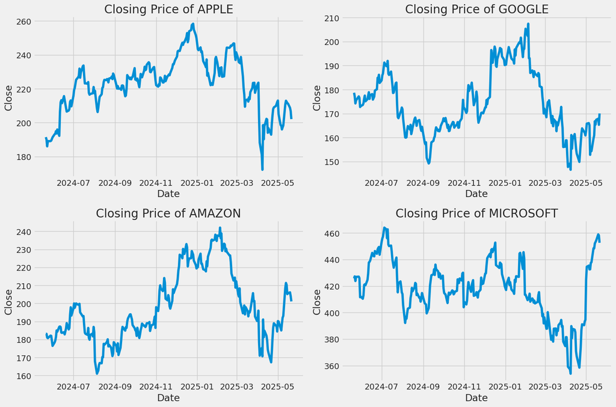

```python
plt.figure(figsize=(15, 10))
plt.subplots_adjust(top=1.25, bottom=1.2)

for i, (ticker, name) in enumerate(zip(tech_list, company_name), 1):
    plt.subplot(2, 2, i)
    company_df = df[df['Ticker'] == ticker]
    plt.plot(company_df['Date'], company_df['Close'])
    plt.ylabel('Close')
    plt.xlabel('Date')
    plt.title(f"Closing Price of {name}")

plt.tight_layout()
plt.show()
```

# This chart tracks the daily closing prices of Apple, Google, Amazon, and Microsoft over the past year.

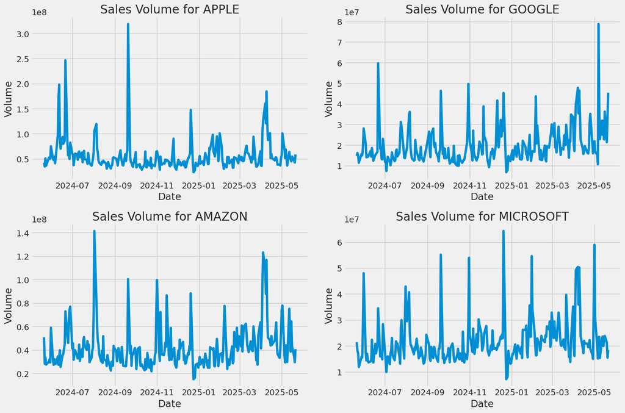

```python
plt.figure(figsize=(15, 10))
plt.subplots_adjust(top=1.25, bottom=1.2)

for i, (ticker, name) in enumerate(zip(tech_list, company_name), 1):
    plt.subplot(2, 2, i)
    company_df = df[df['Ticker'] == ticker]
    plt.plot(company_df['Date'], company_df['Volume'])
    plt.ylabel('Volume')
    plt.xlabel('Date')
    plt.title(f"Sales Volume for {name}")

plt.tight_layout()
plt.show()
```

# This graph displays the number of shares traded each day for each company.

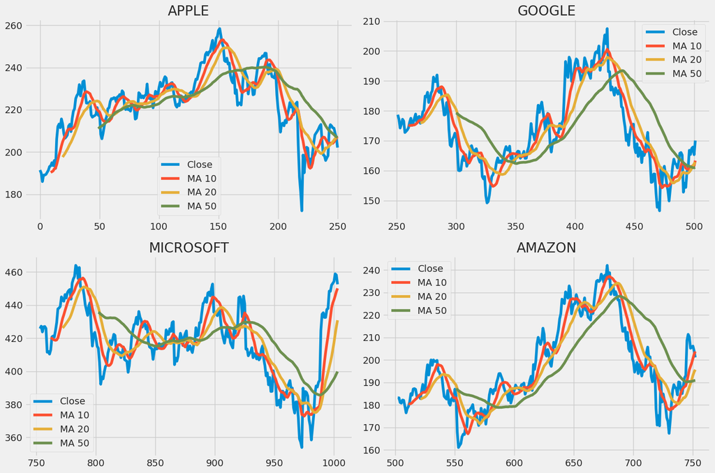

```python
ma_day = [10, 20, 50]
tickers = ['AAPL', 'GOOG', 'MSFT', 'AMZN']
names = ['APPLE', 'GOOGLE', 'MICROSOFT', 'AMAZON']

# Calculate moving averages per ticker
for ticker in tickers:
    for ma in ma_day:
        col_name = f"MA {ma}"
        df.loc[df['Ticker'] == ticker, col_name] = (
            df[df['Ticker'] == ticker]['Close'].rolling(ma).mean()
        )

# Plot each company’s moving averages
fig, axes = plt.subplots(nrows=2, ncols=2, figsize=(15, 10))

for ax, ticker, name in zip(axes.flat, tickers, names):
    sub_df = df[df['Ticker'] == ticker]
    sub_df[['Close', 'MA 10', 'MA 20', 'MA 50']].plot(ax=ax)
    ax.set_title(name)

plt.tight_layout()
plt.show()
```

Moving averages help identify trend direction and potential buy/sell signals. For example, when a short-term average crosses above a long-term average (a golden cross), it may indicate bullish momentum — a potential buy signal. Conversely, when it crosses below (a death cross), it can signal weakening momentum. Investors can use these trends to time entries and exits more effectively.

```python
df['Daily Return'] = df.groupby('Ticker')['Close'].pct_change()
```

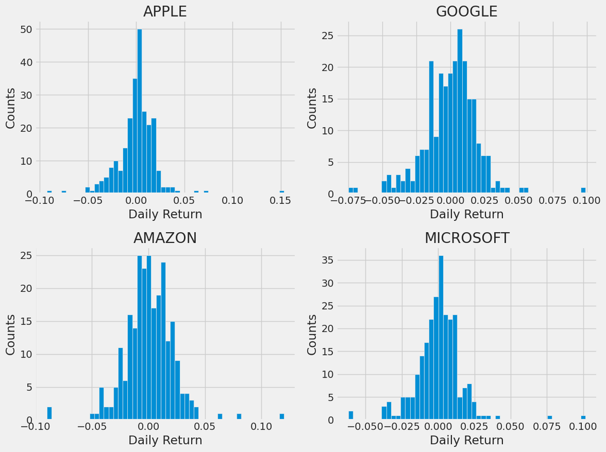

```python
plt.figure(figsize=(12, 9))

for i, (ticker, name) in enumerate(zip(tech_list, company_name), 1):
    plt.subplot(2, 2, i)
    sub_df = df[df['Ticker'] == ticker]
    sub_df['Daily Return'].hist(bins=50)
    plt.xlabel('Daily Return')
    plt.ylabel('Counts')
    plt.title(f'{name}')

plt.tight_layout()
plt.show()
```

# This shows the distribution of each stock’s daily return — how much the price changes from one day to the next.

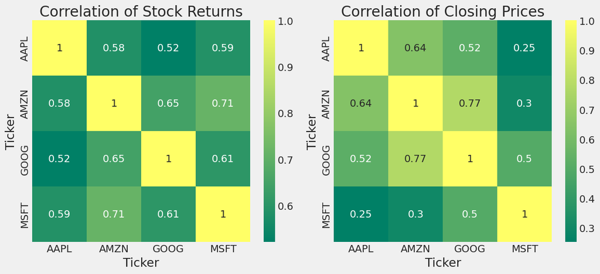

```python
import seaborn as sns
import matplotlib.pyplot as plt

# Pivot close prices and compute returns
closing_df = df.pivot(index='Date', columns='Ticker', values='Close')
tech_rets = closing_df.pct_change()

# Plot correlation heatmaps
plt.figure(figsize=(12, 10))

plt.subplot(2, 2, 1)
sns.heatmap(tech_rets.corr(), annot=True, cmap='summer')
plt.title('Correlation of Stock Returns')

plt.subplot(2, 2, 2)
sns.heatmap(closing_df.corr(), annot=True, cmap='summer')
plt.title('Correlation of Closing Prices')

plt.tight_layout()
plt.show()
```

Return correlation helps with diversification. Owning correated stocks might not reduce risk significantly. Investors looking to diversify would benefit from combining stocks with lower correlations. Price correlation offers less insight for allocation decisions but reinforces relative valuation patterns across the companies.

# PREDICTING APPLE STOCK CLOSING PRICES

```python
import yfinance as yf
from datetime import datetime

df = yf.download('AAPL', start='2012-01-01', end=datetime.now())
df.head()
```

```
[*********************100%***********************]  1 of 1 completed
```

| Price Ticker Date | Close AAPL | High AAPL | Low AAPL | Open AAPL | Volume AAPL |
| --- | --- | --- | --- | --- | --- |
| 2012-01-03 | 12.359182 | 12.397352 | 12.292162 | 12.304184 | 302220800 |
| 2012-01-04 | 12.425604 | 12.462872 | 12.300579 | 12.322217 | 260022000 |
| 2012-01-05 | 12.563551 | 12.579179 | 12.402460 | 12.470984 | 271269600 |
| 2012-01-06 | 12.694890 | 12.705409 | 12.599318 | 12.615848 | 318292800 |
| 2012-01-09 | 12.674750 | 12.855677 | 12.663329 | 12.788055 | 394024400 |

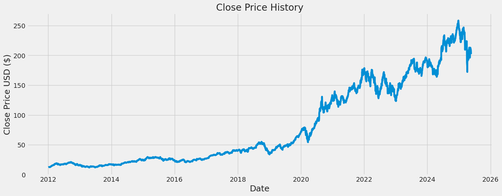

```python
plt.figure(figsize=(16,6))
plt.title('Close Price History')
plt.plot(df['Close'])
plt.xlabel('Date', fontsize=18)
plt.ylabel('Close Price USD ($)', fontsize=18)
plt.show()
```

This long-term upward trajectory demonstrates Apple’s consistent growth and historical resilience. Long-term investors are likely to view this as confirmation of Apple’s value as a core holding. However, any sharp dips serve as reminders that even market leaders experience periods of drawdown, reinforcing the importance of holding power or timing strategies.

```python
# Create a new dataframe with only the 'Close column
data = df[[('Close', 'AAPL')]]
# Convert the dataframe to a numpy array
dataset = data.values
# Get the number of rows to train the model on
training_data_len = int(np.ceil( len(dataset) * .95 ))

training_data_len
```

```
3198
```

```python
# Scale the data
from sklearn.preprocessing import MinMaxScaler

scaler = MinMaxScaler(feature_range=(0,1))
scaled_data = scaler.fit_transform(dataset)

scaled_data
```

```
array([[0.00182111],
       [0.00209059],
       [0.00265024],
       ...,
       [0.7987042 ],
       [0.79091473],
       [0.77156273]])
```

```python
train_data = scaled_data[0:int(training_data_len), :]
# Split the data into x_train and y_train data sets
x_train = []
y_train = []

for i in range(60, len(train_data)):
    x_train.append(train_data[i-60:i, 0])
    y_train.append(train_data[i, 0])
    if i<= 61:
        print(x_train)
        print(y_train)
        print()

# Convert the x_train and y_train to numpy arrays
x_train, y_train = np.array(x_train), np.array(y_train)

# Reshape the data
x_train = np.reshape(x_train, (x_train.shape[0], x_train.shape[1], 1))
# x_train.shape
```

```
[array([0.00182111, 0.00209059, 0.00265024, 0.00318308, 0.00310138,
       0.0032855 , 0.00320138, 0.00305992, 0.00286727, 0.00346352,
       0.00400124, 0.00383541, 0.00292702, 0.00379394, 0.00294044,
       0.0061411 , 0.00589359, 0.0062167 , 0.00691537, 0.00733846,
       0.00730312, 0.00717264, 0.00772866, 0.00825172, 0.0088443 ,
       0.00980148, 0.01181209, 0.01184257, 0.01296189, 0.01379834,
       0.01236078, 0.01291435, 0.01290339, 0.01445553, 0.01423484,
       0.01464332, 0.01537733, 0.01578582, 0.01696246, 0.0178196 ,
       0.01806713, 0.01815372, 0.01668809, 0.0163345 , 0.01638693,
       0.01776474, 0.01815248, 0.01898528, 0.02094833, 0.0235674 ,
       0.02307726, 0.02307847, 0.02497206, 0.02556465, 0.02514274,
       0.02475742, 0.02435631, 0.02568898, 0.02660347, 0.02698633])]
[0.02604014616035709]

[array([0.00182111, 0.00209059, 0.00265024, 0.00318308, 0.00310138,
       0.0032855 , 0.00320138, 0.00305992, 0.00286727, 0.00346352,
       0.00400124, 0.00383541, 0.00292702, 0.00379394, 0.00294044,
       0.0061411 , 0.00589359, 0.0062167 , 0.00691537, 0.00733846,
       0.00730312, 0.00717264, 0.00772866, 0.00825172, 0.0088443 ,
       0.00980148, 0.01181209, 0.01184257, 0.01296189, 0.01379834,
       0.01236078, 0.01291435, 0.01290339, 0.01445553, 0.01423484,
       0.01464332, 0.01537733, 0.01578582, 0.01696246, 0.0178196 ,
       0.01806713, 0.01815372, 0.01668809, 0.0163345 , 0.01638693,
       0.01776474, 0.01815248, 0.01898528, 0.02094833, 0.0235674 ,
       0.02307726, 0.02307847, 0.02497206, 0.02556465, 0.02514274,
       0.02475742, 0.02435631, 0.02568898, 0.02660347, 0.02698633]), array([0.00209059, 0.00265024, 0.00318308, 0.00310138, 0.0032855 ,
       0.00320138, 0.00305992, 0.00286727, 0.00346352, 0.00400124,
       0.00383541, 0.00292702, 0.00379394, 0.00294044, 0.0061411 ,
       0.00589359, 0.0062167 , 0.00691537, 0.00733846, 0.00730312,
       0.00717264, 0.00772866, 0.00825172, 0.0088443 , 0.00980148,
       0.01181209, 0.01184257, 0.01296189, 0.01379834, 0.01236078,
       0.01291435, 0.01290339, 0.01445553, 0.01423484, 0.01464332,
       0.01537733, 0.01578582, 0.01696246, 0.0178196 , 0.01806713,
       0.01815372, 0.01668809, 0.0163345 , 0.01638693, 0.01776474,
       0.01815248, 0.01898528, 0.02094833, 0.0235674 , 0.02307726,
       0.02307847, 0.02497206, 0.02556465, 0.02514274, 0.02475742,
       0.02435631, 0.02568898, 0.02660347, 0.02698633, 0.02604015])]
[0.02604014616035709, 0.024783075841081068]
```

```python
from keras.models import Sequential
from keras.layers import Dense, LSTM

# Build the LSTM model
model = Sequential()
model.add(LSTM(128, return_sequences=True, input_shape= (x_train.shape[1], 1)))
model.add(LSTM(64, return_sequences=False))
model.add(Dense(25))
model.add(Dense(1))

# Compile the model
model.compile(optimizer='adam', loss='mean_squared_error')

# Train the model
model.fit(x_train, y_train, batch_size=1, epochs=1)
```

```
3138/3138 ━━━━━━━━━━━━━━━━━━━━ 73s 23ms/step - loss: 0.0016
```

```
<keras.src.callbacks.history.History at 0xffff58663fb0>
```

```python
# Create the testing data set
# Create a new array containing scaled values from index 1543 to 2002
test_data = scaled_data[training_data_len - 60: , :]
# Create the data sets x_test and y_test
x_test = []
y_test = dataset[training_data_len:, :]
for i in range(60, len(test_data)):
    x_test.append(test_data[i-60:i, 0])

# Convert the data to a numpy array
x_test = np.array(x_test)

# Reshape the data
x_test = np.reshape(x_test, (x_test.shape[0], x_test.shape[1], 1 ))

# Get the models predicted price values
predictions = model.predict(x_test)
predictions = scaler.inverse_transform(predictions)

# Get the root mean squared error (RMSE)
rmse = np.sqrt(np.mean(((predictions - y_test) ** 2)))
rmse
```

```
6/6 ━━━━━━━━━━━━━━━━━━━━ 0s 26ms/step
```

```
6.9713873564172015
```

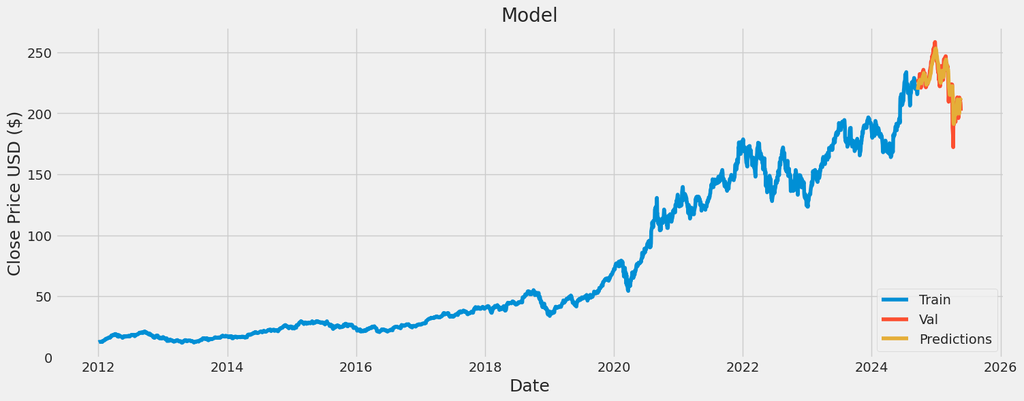

```python
train = data[:training_data_len]
valid = data[training_data_len:]
valid['Predictions'] = predictions
# Visualize the data
plt.figure(figsize=(16,6))
plt.title('Model')
plt.xlabel('Date', fontsize=18)
plt.ylabel('Close Price USD ($)', fontsize=18)
plt.plot(train['Close'])
plt.plot(valid[['Close', 'Predictions']])
plt.legend(['Train', 'Val', 'Predictions'], loc='lower right')
plt.show()
```

```python
valid
```

| Price Ticker Date | Close AAPL | Predictions |
| --- | --- | --- |
| 2024-09-19 | 228.068298 | 219.200668 |
| 2024-09-20 | 227.400650 | 220.887085 |
| 2024-09-23 | 225.676727 | 222.868073 |
| 2024-09-24 | 226.573563 | 224.243729 |
| 2024-09-25 | 225.577057 | 225.254639 |
| ... | ... | ... |
| 2025-05-15 | 211.449997 | 207.989456 |
| 2025-05-16 | 211.259995 | 210.075439 |
| 2025-05-19 | 208.779999 | 211.296631 |
| 2025-05-20 | 206.860001 | 211.408905 |
| 2025-05-21 | 202.089996 | 210.668106 |

168 rows × 2 columns

```python
from sklearn.metrics import mean_squared_error, mean_absolute_error, r2_score
```

```python
y_true = valid[('Close', 'AAPL')].values
y_pred = valid['Predictions'].values
```

```python
y_true = valid['Close'].values
```

```python
# Root Mean Squared Error (RMSE)
rmse = np.sqrt(mean_squared_error(y_true, y_pred))

# Mean Absolute Error (MAE)
mae = mean_absolute_error(y_true, y_pred)

# R² Score
r2 = r2_score(y_true, y_pred)

print(f"RMSE: {rmse:.2f}")
print(f"MAE: {mae:.2f}")
print(f"R² Score: {r2:.4f}")
```

```
RMSE: 6.97
MAE: 5.07
R² Score: 0.8125
```

These metrics suggest the model’s predictions are, on average, within $5–7 of the actual closing price, a strong performance considering Apple trades above $200. For quantitative investors, this level of accuracy may justify using the model to assist (not replace) human judgment. The R² score indicates that the model explains over 81% of the variation in price, which adds confidence for future deployment.